# Задачи по Эконометрике: Серийная корреляция

Н.В. Артамонов (МГИМО МИД России)

# 1 DW-тест

## 1.1 Icecream consumption

Рассмотрим набор данных `Icecream`: Недельные данные по потреблению мороженого

- cons (потребление мороженого на одного человека в пинтах)
- income (средний недельных доход семьи)
- price (цена мороженого за пинту)
- temp (средняя температура по Фаренгейту)

и регрессию **cons на income, price, temp**. Результаты подгонки

```
MODEL INFO:
Observations: 30
Dependent Variable: cons
Type: OLS linear regression

MODEL FIT:
F(3,26) = 22.17, p = 0.00
R² = 0.72
Adj. R² = 0.69

Standard errors: OLS
------------------------------------------------
                     Est.   S.E.   t val.      p
----------------- ------- ------ -------- ------
(Intercept)          0.20   0.27     0.73   0.47
income               0.00   0.00     2.82   0.01
price               -1.04   0.83    -1.25   0.22
temp                 0.00   0.00     7.76   0.00
------------------------------------------------
```

Модель с серийной корреляцией первого порядка

$cons_t=\beta_0+\beta_1income_t+\beta_2price_t+\beta_3temp_t+u_t$

$u_t=\rho u_{t-1}+v_t$

DW-тест: теструем $H_0:\rho=0$ vs $H_1:\rho\ne0$.

Результаты теста:

```
    Durbin-Watson test

data:  regr
DW = 1.0212, p-value = 0.0006048
alternative hypothesis: true autocorrelation is not 0
```

Уровень значимости 5%. Какие можно сделать выводы?

```
[1] "Гипотеза отвергается, есть серийная корреляция"
```

Какие критические значения?

## 1.2 Consumption equation

Для набора данных `Consumption` рассморим регессию с серийно коррецяией первого порядка

Модель с серийной корреляцией первого порядка

$\Delta\log(yd_t)=\beta_0+\beta_1\Delta\log(ce_t)+u_t$

$u_t=\rho u_{t-1}+v_t$

Результаты подгонки

```
MODEL INFO:
Observations: 199
Dependent Variable: diff(log(yd))
Type: OLS linear regression

MODEL FIT:
F(1,197) = 30.06, p = 0.00
R² = 0.13
Adj. R² = 0.13

Standard errors: OLS
-------------------------------------------------
                      Est.   S.E.   t val.      p
------------------- ------ ------ -------- ------
(Intercept)           0.01   0.00     5.25   0.00
diff(log(ce))         0.37   0.07     5.48   0.00
-------------------------------------------------
```

DW-тест: теструем $H_0:\rho=0$ vs $H_1:\rho\ne0$.

Результаты теста:

```
    Durbin-Watson test

data:  regr
DW = 2.3821, p-value = 0.006613
alternative hypothesis: true autocorrelation is not 0
```

Уровень значимости 1%. Какие можно сделать выводы?

```
[1] "Гипотеза отвергается, есть серийная корреляция"
```

Какие критические значения?

## 1.3 M2 и ставки

Рассморим данные по M2, краткосрочной и долгосрочной ставке (месячные данные с 1995 по 2019) Загрузим данные из БД [FRED](https://fred.stlouisfed.org)

Построим графики ставок и первых разностей

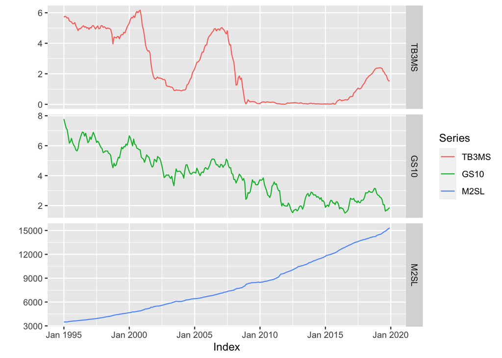

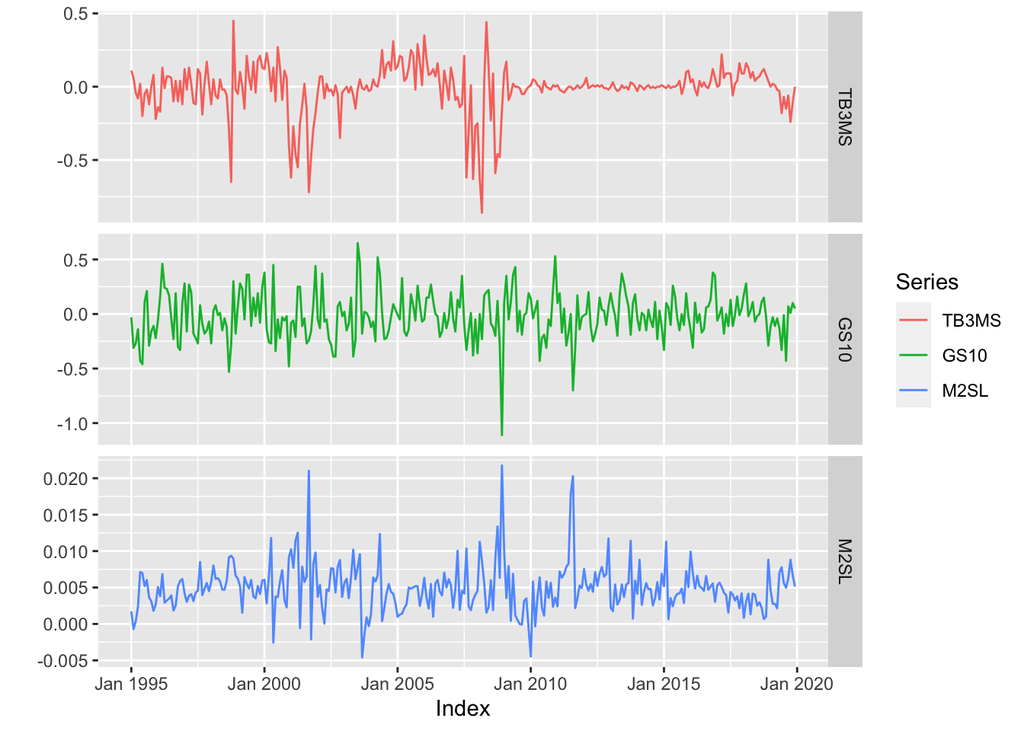

Рассмотрим регрессию $\Delta rate.10y_t=\beta_0+\beta_1\Delta rate.3m_t+\beta_2\Delta\log M2_t+u_t$ с серийной корреляцией первого порядка $u_t=\rho u_{t-1}+v_t$

Результаты подгонки

```
MODEL INFO:
Observations: 300
Dependent Variable: d.rate.10y
Type: OLS linear regression

MODEL FIT:
F(2,297) = 18.42, p = 0.00
R² = 0.11
Adj. R² = 0.10

Standard errors: OLS
------------------------------------------------
                     Est.   S.E.   t val.      p
----------------- ------- ------ -------- ------
(Intercept)          0.03   0.02     1.23   0.22
d.rate.3m            0.34   0.07     4.53   0.00
dl.M2               -8.51   3.77    -2.26   0.02
------------------------------------------------
```

DW-тест: теструем $H_0:\rho=0$ vs $H_1:\rho\ne0$

Результаты теста:

```
    Durbin-Watson test

data:  regr
DW = 1.6037, p-value = 0.0005007
alternative hypothesis: true autocorrelation is not 0
```

Уровень значимости 5%. Какие можно сделать выводы?

```
[1] "Гипотеза отвергается, есть серийная корреляция"
```

Какие критические значения?

# 2 LM/BG-тест

## 2.1 Consumption equation

Для набора данных `Consumption` рассморим регессию с серийно коррецяией третьего порядка

$\Delta\log(yd_t)=\beta_0+\beta_1\Delta\log(ce_t)+u_t$

$u_t=\rho_1 u_{t-1}+\rho_2 u_{t-2}+\rho_3u_{t-3}+v_t$

Результаты подгонки

```
MODEL INFO:
Observations: 199
Dependent Variable: diff(log(yd))
Type: OLS linear regression

MODEL FIT:
F(1,197) = 30.06, p = 0.00
R² = 0.13
Adj. R² = 0.13

Standard errors: OLS
-------------------------------------------------
                      Est.   S.E.   t val.      p
------------------- ------ ------ -------- ------
(Intercept)           0.01   0.00     5.25   0.00
diff(log(ce))         0.37   0.07     5.48   0.00
-------------------------------------------------
```

LM/BG-тест: тестируем $H_0:\rho_1=\rho_2=\rho_3=0$

Результаты теста:

```
    Breusch-Godfrey test for serial correlation of order up to 3

data:  regr
LM test = 9.3768, df = 3, p-value = 0.02468
```

Уровень значимости 1%. Вычислите необходимое критическое значение. **Ответ округлите до 2-х десятичных знаков.**

```
[1] 11.34
```

Какие можно сделать выводы?

```
[1] "Гипотеза не отвергается, нет серийной корреляции"
```

## 2.2 M2 и ставки

Рассморим данные по M2, краткосрочной и долгосрочной ставке (месячные данные с 1995 по 2019) Загрузим данные из БД [FRED](https://fred.stlouisfed.org)

Рассмотрим регрессию $\Delta rate.10y_t=\beta_0+\beta_1\Delta rate.3m_t+\beta_2\Delta\log M2_t+u_t$ с серийной корреляцией второго порядка $u_t=\rho_1 u_{t-1}+\rho_2 u_{t-2}+v_t$

Результаты подгонки

```
MODEL INFO:
Observations: 300
Dependent Variable: d.rate.10y
Type: OLS linear regression

MODEL FIT:
F(2,297) = 18.42, p = 0.00
R² = 0.11
Adj. R² = 0.10

Standard errors: OLS
------------------------------------------------
                     Est.   S.E.   t val.      p
----------------- ------- ------ -------- ------
(Intercept)          0.03   0.02     1.23   0.22
d.rate.3m            0.34   0.07     4.53   0.00
dl.M2               -8.51   3.77    -2.26   0.02
------------------------------------------------
```

LM/BG-тест: тестируем $H_0:\rho_1=\rho_2=0$

Результаты теста:

```
    Breusch-Godfrey test for serial correlation of order up to 2

data:  regr
LM test = 16.571, df = 2, p-value = 0.0002522
```

Уровень значимости 5%. Вычислите необходимое критическое значение. **Ответ округлите до 2-х десятичных знаков.**

```
[1] 5.99
```

Какие можно сделать выводы?

```
[1] "Гипотеза отвергается, есть серийная корреляция"
```

# 3 Робастный t-тест (HAC s.e.)

## 3.1 Icecream consumption

Рассмотрим набор данных `Icecream` и регрессию **cons на income, price, temp**.

Результаты подгонки (неробастные OLS-s.e.)

```
MODEL INFO:
Observations: 30
Dependent Variable: cons
Type: OLS linear regression

MODEL FIT:
F(3,26) = 22.175, p = 0.000
R² = 0.719
Adj. R² = 0.687

Standard errors: OLS
---------------------------------------------------
                      Est.    S.E.   t val.       p
----------------- -------- ------- -------- -------
(Intercept)          0.197   0.270    0.730   0.472
income               0.003   0.001    2.824   0.009
price               -1.044   0.834   -1.252   0.222
temp                 0.003   0.000    7.762   0.000
---------------------------------------------------
```

Результаты подгонки (робастные HAC-s.e.)

```
MODEL INFO:
Observations: 30
Dependent Variable: cons
Type: OLS linear regression

MODEL FIT:
F(3,26) = 22.175, p = 0.000
R² = 0.719
Adj. R² = 0.687

---------------------------------------------------
                      Est.    S.E.   t val.       p
----------------- -------- ------- -------- -------
(Intercept)          0.197   0.356    0.554   0.584
income               0.003   0.001    2.396   0.024
price               -1.044   1.018   -1.026   0.315
temp                 0.003   0.000    8.991   0.000
---------------------------------------------------
```

Уровень значимости 1%. Какие коэффициенты значимы?

```
   regressors sign.regressors
1 (Intercept)        Незначим
2      income        Незначим
3       price        Незначим
4        temp          Значим
```

## 3.2 M2 и ставки

Рассморим данные по M2, краткосрочной и долгосрочной ставке (месячные данные с 1995 по 2019) Загрузим данные из БД [FRED](https://fred.stlouisfed.org)

Рассмотрим регрессию $\Delta rate.10y_t=\beta_0+\beta_1\Delta rate.3m_t+\beta_2\Delta\log M2_t+u_t$

Результаты подгонки (неробастные OLS-s.e.)

```
MODEL INFO:
Observations: 300
Dependent Variable: d.rate.10y
Type: OLS linear regression

MODEL FIT:
F(2,297) = 18.423, p = 0.000
R² = 0.110
Adj. R² = 0.104

Standard errors: OLS
---------------------------------------------------
                      Est.    S.E.   t val.       p
----------------- -------- ------- -------- -------
(Intercept)          0.027   0.022    1.230   0.220
d.rate.3m            0.335   0.074    4.534   0.000
dl.M2               -8.514   3.772   -2.257   0.025
---------------------------------------------------
```

Результаты подгонки (робастные HAC-s.e.)

```
MODEL INFO:
Observations: 300
Dependent Variable: d.rate.10y
Type: OLS linear regression

MODEL FIT:
F(2,297) = 18.423, p = 0.000
R² = 0.110
Adj. R² = 0.104

---------------------------------------------------
                      Est.    S.E.   t val.       p
----------------- -------- ------- -------- -------
(Intercept)          0.027   0.030    0.896   0.371
d.rate.3m            0.335   0.074    4.538   0.000
dl.M2               -8.514   6.486   -1.313   0.190
---------------------------------------------------
```

Уровень значимости 5%. Какие коэффициенты значимы?

```
   regressors sign.regressors
1 (Intercept)        Незначим
2   d.rate.3m          Значим
3       dl.M2        Незначим
```

# 4 Python (практика)

## 4.1 Mishkin dataset

Для датасета `Mishkin` (месячные данные с 1950-2 по 1990-12) рассмотрим модель **$\Delta$pai3 on $\Delta$tb3, $\Delta$log(cpi)**

– Подгоните модель и тестируйте на автокорреляцию первого порядка

– Подгоните модель и тестируйте на автокорреляцию второго порядка

– проведите робастный и неробастный t-тест и сравните результат

– проведите робастный и неробастный F-тест на значимость регресии и сравните результат

## 4.2 Tbrate dataset

Для датасета `Tbrate` (квартальные данные с 1950-1 по 1996-4) рассмотрим модель **$\Delta$pi on $\Delta$y, $\Delta$r**

– Подгоните модель и тестируйте на автокорреляцию первого порядка

– Подгоните модель и тестируйте на автокорреляцию второго порядка

– проведите робастный и неробастный t-тест и сравните результат

– проведите робастный и неробастный F-тест на значимость регресии и сравните результат

## 4.3 MoneyUS dataset

Для датасета `MoneyUS` (квартальные данные с 1954–01 по 1994–12) рассмотрим модель **infl on $\Delta$y, $\Delta$tbr, $\Delta$cpr, $\Delta$m**

– Подгоните модель и тестируйте на автокорреляцию первого порядка

– Подгоните модель и тестируйте на автокорреляцию второго порядка

– проведите робастный и неробастный t-тест и сравните результат

– проведите робастный и неробастный F-тест на значимость регресии и сравните результат

## 4.4 Macrodat dataset

Для датасета `Macrodat` (квартальные данные с 1959-1 по 2000-4) рассмотрим модель **lhur on $\Delta$log(punew), $\Delta$fyff, $\Delta$fygm3, $\Delta$fygt1, $\Delta$log(gdpjp)**

– Подгоните модель и тестируйте на автокорреляцию первого порядка

– Подгоните модель и тестируйте на автокорреляцию второго порядка

– проведите робастный и неробастный t-тест и сравните результат

– проведите робастный и неробастный F-тест на значимость регресии и сравните результат

# 5 M2 и спреды

Из БД [FRED](https://fred.stlouisfed.org/) загрузим месячные данные

- M2 (M2SL)
- 3-Month Treasury Bill Secondary (TB3MS)
- Market Yield on U.S. Treasury Securities at 10-Year Constant Maturity (GS10)
- Market Yield on U.S. Treasury Securities at 1-Year Constant Maturity (GS1)
- Moody’s Seasoned Aaa Corporate Bond Yield (AAA)
- Moody’s Seasoned Baa Corporate Bond Yield (BAA)

c 2001-01 по 2022-12

Рассморим регрессию первую разность спреда ставок BAA & AAA на первую разность спред ставок GS10 & TB3MS и первуб разность log(M2).

– Сформируйте датасет

– Подгоните модель и тестируйте на автокорреляцию порядка

– проведите робастный и неробастный t-тест и сравните результат

– проведите робастный и неробастный F-тест на значимость регресии и сравните результат